# PEC2 - Visualización de datos

# Creación Bullet Graph.

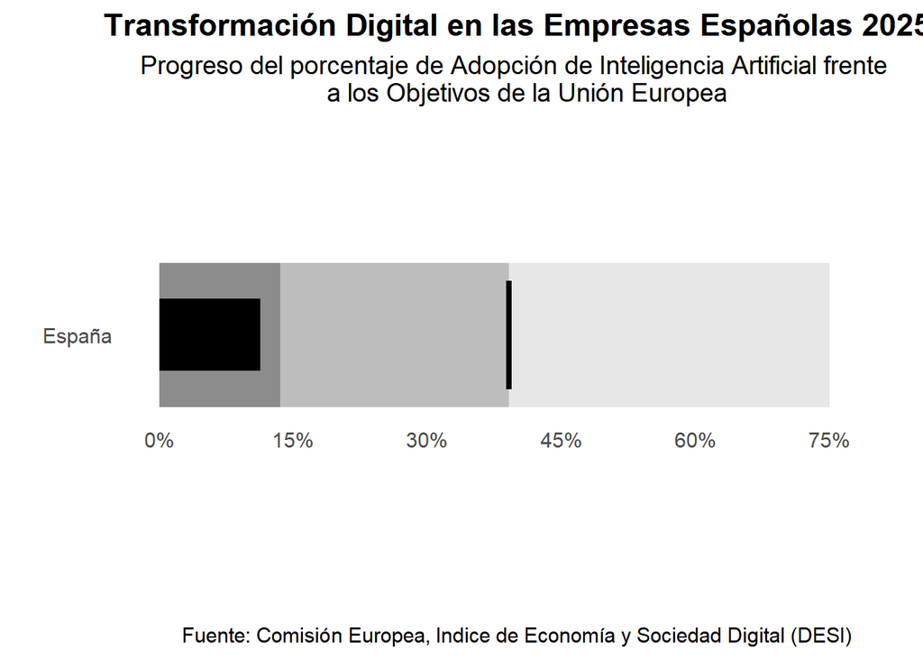

```r
# Bullet Graph.

bullet_graph_ia <- ggplot(datos_España, aes(y = label_pais)) +

  # Capas de rangos
  geom_col(aes(x = obj_final_2030), fill = "#E6E6E6", width = 0.4) +
  geom_col(aes(x = obj_ideal_2025), fill = "#BDBDBD", width = 0.4) +
  geom_col(aes(x = obj_base_2025), fill = "#8C8C8C", width = 0.4) +

  # Barra negra (valor actual)
  geom_col(aes(x = value), fill = "black", width = 0.2) +


  # Línea del objetivo ideal
  geom_segment(
    # --- AÑADE ESTA LÍNEA PARA FILTRAR ---
    data = . %>% filter(country == "ES"),

    aes(
      x = obj_ideal_2025, xend = obj_ideal_2025,
      y = as.numeric(factor(label_pais)) - 0.15,
      yend = as.numeric(factor(label_pais)) + 0.15
      ), color = "black", linewidth = 1.5
    ) +

  # Escala X
  scale_x_continuous(
    limits = c(0, 80),
    breaks = seq(0, 75, by = 15),
    labels = c("0%", "15%", "30%", "45%", "60%", "75%")
  ) +

  labs(
    title = "Transformación Digital en las Empresas Españolas 2025",
    subtitle = "Progreso del porcentaje de Adopción de Inteligencia Artificial frente
    a los Objetivos de la Unión Europea ",
    x = "",
    y = "",
    caption = "Fuente: Comisión Europea, Indice de Economía y Sociedad Digital (DESI)"
  ) +

  theme_minimal(base_size = 14) +
  theme(
    plot.title = element_text(hjust = 0.5, face = "bold"),
    plot.subtitle = element_text(hjust = 0.5),
    plot.caption = element_text(hjust = 0.5),
    panel.grid.major.y = element_blank(),
    panel.grid.major.x = element_blank(),
    panel.grid.minor.x = element_blank(),
    axis.text.x = element_text(vjust = 33),
    legend.position = "none"
  )
print(bullet_graph_ia)
```

```r
# Guardar el gráfico
ggsave(
  "bullet_graph_ia.png",
  plot = bullet_graph_ia,
  width = 10,
  height = 5.625,
  units = "in",
  dpi = 300
)
```

# 6. Creación de Voronoi

Los Centros Europeos de Innovación Digital (EDIH) son ventanillas únicas que ayudan a las empresas y organizaciones del sector público a responder a los desafíos digitales:

- Proporcionan acceso a conocimientos técnicos y pruebas.
- Proporcionan Servicios de Innovación, como asesoramiento para una transformación digital exitosa.
- ayuda a las empresas en el uso de tecnologías digitales para la sostenibilidad y la circularidad.

En este apartado se extraen los datos de los EDIH, para crear un mapa de Voronoi de los que se encuentran en España.

```r
library(readxl)
library(dplyr)
library(tidygeocoder)
library(ggplot2)
library(ggforce)
library(maps)
library(sf)
# Carga el archivo de Excel
edih_raw <- read_excel("edihs_ia_spain.xlsx")

# 1. Filtra por España.
# 2. Selecciona las columnas necesarias para geocodificar y colorear.
edih_spain_seleccionado <- edih_raw %>%
  filter(Country == "Spain") %>%
  select(`EDIH Name`, Provincia)

# Geocodifica la columna 'Provincia' para obtener 'lat' y 'lon'
edih_hubs_coords <- edih_spain_seleccionado %>%
  geocode(address = Provincia, method = "osm")
```

```
## Passing 20 addresses to the Nominatim single address geocoder
```

```
## Query completed in: 20.4 seconds
```

```r
print(edih_hubs_coords)
```

```
## # A tibble: 25 × 4
##    `EDIH Name`         Provincia                lat   long
##    <chr>               <chr>                  <dbl>  <dbl>
##  1 CIDAI               Barcelona               41.4  2.18
##  2 AGORA DIH           Murcia                  38.0 -1.13
##  3 AgrotechDIH         Sevilla                 37.4 -6.00
##  4 AIR-Andalusia       Granada                 37.2 -3.60
##  5 AIR4S               Madrid                  40.4 -3.70
##  6 Aragon EDIH         Zaragoza                41.7 -0.881
##  7 AsDIH               Llanera(Asturias)       43.5 -5.85
##  8 DATAlife            Santiago de Compostela  42.9 -8.55
##  9 DIGIS3              Salamanca               41.0 -5.66
## 10 Digital Impulse Hub Terrassa, Barcelona     41.6  2.01
## # ℹ 15 more rows
```

Generación del gráfico Voronoi.

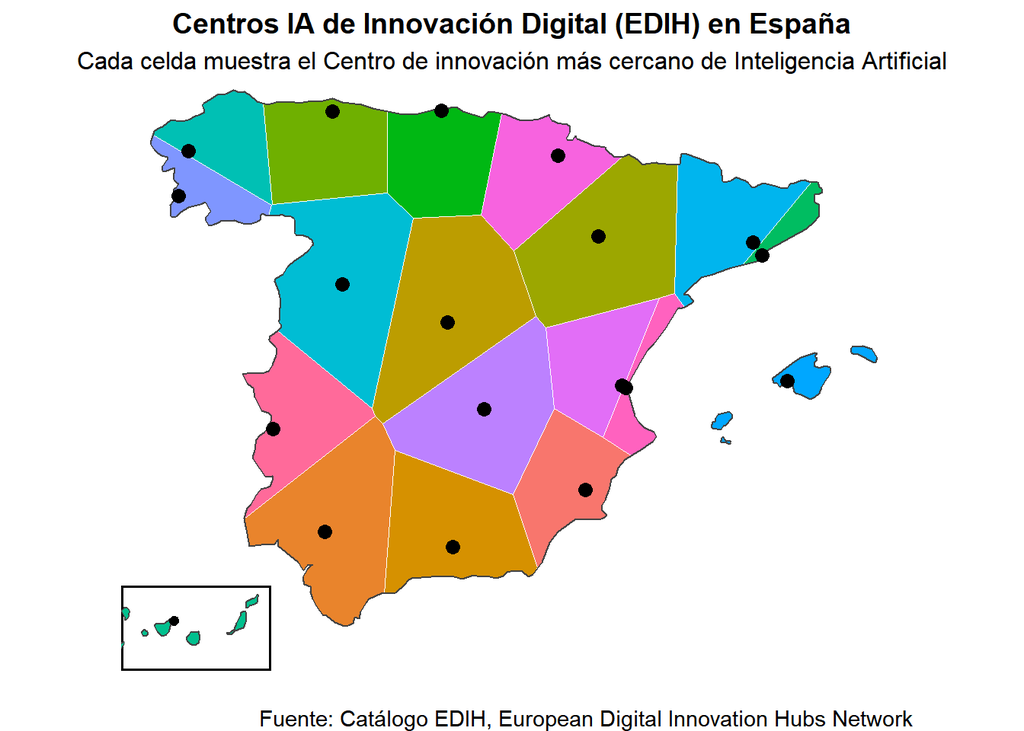

```r
# Carga el contorno de España para el mapa (incluye Canarias)
contorno_espana <- map_data("world", region = c("Spain", "Canary Islands"))

# Convierte el contorno a polígono sf
espana_sf <- contorno_espana %>%
  st_as_sf(coords = c("long", "lat"), crs = 4326) %>%
  group_by(group) %>%
  summarise(geometry = st_combine(geometry), .groups = "drop") %>%
  st_cast("POLYGON") %>%
  st_union()

# Convierte los puntos EDIH a sf CON LA COLUMNA EDIH Name
puntos_sf <- edih_hubs_coords %>%
  st_as_sf(coords = c("long", "lat"), crs = 4326)

# Genera el diagrama de Voronoi
voronoi_todos <- st_voronoi(st_union(puntos_sf)) %>%
  st_collection_extract("POLYGON") %>%
  st_as_sf() # Convierte a sf

# Recorta al polígono de España
voronoi_recortado <- st_intersection(voronoi_todos, espana_sf) %>%
  st_as_sf()

# Asigna cada polígono Voronoi al punto EDIH más cercano
# Usa st_nearest_feature para asegurar que cada polígono va al punto más cercano
nearest_idx <- st_nearest_feature(voronoi_recortado, puntos_sf)
voronoi_con_datos <- voronoi_recortado %>%
  mutate(`EDIH Name` = puntos_sf$`EDIH Name`[nearest_idx])

# Crea el Gráfico Voronoi PRINCIPAL (Sin Canarias)
grafico_principal <- ggplot() +

  # Dibuja las teselas de Voronoi recortadas con color por EDIH Name
  geom_sf(data = voronoi_con_datos,
          aes(fill = `EDIH Name`),
          colour = "white",
          linewidth = 0.3,
          show.legend = FALSE) +

  # Dibuja el contorno de España
  geom_polygon(
    data = contorno_espana %>% filter(region == "Spain"),
    aes(x = long, y = lat, group = group),
    fill = NA,
    color = "#444444",
    linewidth = 0.5
  ) +

  # Dibuja los puntos de los EDIH
  geom_sf(data = puntos_sf, color = "black", size = 3) +

  coord_sf(xlim = c(-10, 5), ylim = c(35, 44), expand = FALSE) +

  theme_void(base_size = 12) +
  labs(
    title = "Centros IA de Innovación Digital (EDIH) en España",
    subtitle = "Cada celda muestra el Centro de innovación más cercano de Inteligencia Artificial",
    caption = "Fuente: Catálogo EDIH, European Digital Innovation Hubs Network"
  ) +
  theme(
    plot.title = element_text(hjust = 0.5, face = "bold", size = 14),
    plot.subtitle = element_text(hjust = 0.5, size = 12),
    plot.caption = element_text(size = 11, hjust = 1)
  )

  # Crea el gráfico INSET para Canarias
    grafico_canarias <- ggplot() +

  # Dibuja las teselas de Voronoi recortadas
  geom_sf(data = voronoi_con_datos,
          aes(fill = `EDIH Name`),
          colour = "white",
          linewidth = 0.2,
          show.legend = FALSE) +

  # Dibuja el contorno de Canarias
  geom_polygon(
    data = contorno_espana %>% filter(region == "Canary Islands"),
    aes(x = long, y = lat, group = group),
    fill = NA,
    color = "#444444",
    linewidth = 0.5
  ) +

  # Dibuja los puntos de los EDIH
  geom_sf(data = puntos_sf, color = "black", size = 2) +

  coord_sf(xlim = c(-18, -13), ylim = c(27, 29.5), expand = FALSE) +

  theme_void(base_size = 10) +
  theme(
    plot.background = element_rect(fill = "white", color = "black", linewidth = 1)
  )

# Inclusión de Canarias
grafico_voronoi_edih <- grafico_principal +
  annotation_custom(
    ggplotGrob(grafico_canarias),
    xmin = -9.8, xmax = -7,
    ymin = 35.2, ymax = 36.8
  )

grafico_voronoi_edih <- grafico_voronoi_edih +
  theme(
    plot.background = element_rect(fill = "white", color = NA),
    panel.background = element_rect(fill = "white", color = NA)
  )

print(grafico_voronoi_edih)
```

```r
ggsave(
  "voronoi_edih_spain.png",
  plot = grafico_voronoi_edih,
  width = 14,
  height = 10,
  units = "in",
  dpi = 300,
  bg = "white"
)
```